# Initial descriptive statistics and visualizations

In this document you will find the steps required to perform an initial exploration analysis of the traffic & climate data combined in `R/1-import.R`.

## Load packages

To conduct this analysis we need a few packages loaded in the R environment. `pacman` is used for convenience as it will install (and if required easily update) required packages when not installed. If you prefer you could run `install.packages("packagename")` and `library("packagename")` instead.

```r
pacman::p_load(tidyverse, data.table, lubridate, skimr, knitr, leaflet,RColorBrewer)
```

# 1. Introduction and Data Loading

This report conducts an exploratory data analysis (EDA) of a traffic accident dataset. The goal is to understand the key characteristics of the data, identify patterns, and visualize trends related to when, where, and to whom accidents occur.

## 1.1. Data Loading

First we copy the data, so we always have the original at hand.

```r
source("../R/2-load.R") # load data
accidents <- copy(tpe_hist_accident_weather) # make copy
```

And the data needs to be inspected, to ensure the Taipei accident data is properly loaded, and combined with the climate data. The imported and combined dataset is named *tpe_hist_accident_weather*.

```r
accidents %>% head(n = 10) # display/print the first 10 rows
```

```
##      year month   day  hour minute handling_type district_code
##     <int> <int> <int> <int>  <int>         <int>        <char>
##  1:   105     1     1     0     10             2      04大安區
##  2:   105     1     1     0     10             2      04大安區
##  3:   105     1     1     0     50             2      04大安區
##  4:   105     1     1     0     50             2      04大安區
##  5:   105     1     1     0     56             2      04大安區
##  6:   105     1     1     0     56             2      04大安區
##  7:   105     1     1     0     56             2      12內湖區
##  8:   105     1     1     0     56             2      12內湖區
##  9:   105     1     1     0     56             2      12內湖區
## 10:   105     1     1     1      0             2      10文山區
##                                       location deaths injuries party_id
##                                         <char>  <int>    <int>    <int>
##  1:                   大安區仁愛路與新生南路口      0        1        1
```

[output cut: 273 more lines]

```r
accidents %>% str() # inspect column names and datatype
```

```
## Classes 'data.table' and 'data.frame':   678370 obs. of  97 variables:
##  $ year                             : int  105 105 105 105 105 105 105 105 105 105 ...
##  $ month                            : int  1 1 1 1 1 1 1 1 1 1 ...
##  $ day                              : int  1 1 1 1 1 1 1 1 1 1 ...
##  $ hour                             : int  0 0 0 0 0 0 0 0 0 1 ...
##  $ minute                           : int  10 10 50 50 56 56 56 56 56 0 ...
##  $ handling_type                    : int  2 2 2 2 2 2 2 2 2 2 ...
##  $ district_code                    : chr  "04大安區" "04大安區" "04大安區" "04大安區" ...
##  $ location                         : chr  "大安區仁愛路與新生南路口" "大安區仁愛路與新生南路口" "大安區信義路與建國南路口(南側迴轉道)" "大安區信義路與建國南路口(南側迴轉道)" ...
##  $ deaths                           : int  0 0 0 0 0 0 0 0 0 0 ...
##  $ injuries                         : int  1 1 1 1 1 1 2 2 2 2 ...
##  $ party_id                         : int  1 2 1 2 1 2 1 2 3 1 ...
##  $ vehicle_type                     : chr  "B01" "F01" "B01" "C01" ...
##  $ gender                           : int  1 1 1 1 1 1 1 1 2 1 ...
##  $ age                              : int  58 38 53 26 21 51 32 25 33 19 ...
```

[output cut: 84 more lines]

## 1.2. Initial Data Overview

Let’s start with a high-level overview of the dataset using `glimpse()` to see the column types and `skim()` to get detailed summary statistics, including missing values.

```r
# Glimpse provides a transposed view of str()
glimpse(accidents)
```

```
## Rows: 678,370
## Columns: 97
## $ year                              <int> 105, 105, 105, 105, 105, 105, 105, 1…
## $ month                             <int> 1, 1, 1, 1, 1, 1, 1, 1, 1, 1, 1, 1, …
## $ day                               <int> 1, 1, 1, 1, 1, 1, 1, 1, 1, 1, 1, 1, …
## $ hour                              <int> 0, 0, 0, 0, 0, 0, 0, 0, 0, 1, 1, 2, …
## $ minute                            <int> 10, 10, 50, 50, 56, 56, 56, 56, 56, …
## $ handling_type                     <int> 2, 2, 2, 2, 2, 2, 2, 2, 2, 2, 2, 2, …
## $ district_code                     <chr> "04大安區", "04大安區", "04大安區", "04大安區", …
## $ location                          <chr> "大安區仁愛路與新生南路口", "大安區仁愛路與新生南路口", "大安區…
## $ deaths                            <int> 0, 0, 0, 0, 0, 0, 0, 0, 0, 0, 0, 0, …
## $ injuries                          <int> 1, 1, 1, 1, 1, 1, 2, 2, 2, 2, 2, 1, …
## $ party_id                          <int> 1, 2, 1, 2, 1, 2, 1, 2, 3, 1, 2, 1, …
## $ vehicle_type                      <chr> "B01", "F01", "B01", "C01", "C03", "…
## $ gender                            <int> 1, 1, 1, 1, 1, 1, 1, 1, 2, 1, 1, 1, …
```

[output cut: 84 more lines]

```r
# Skimr provides a powerful and readable summary
# Note: This can be slow on very large datasets. We will look at the first 10k rows.
skim(accidents[1:10000, ])
```

Data summary

| Name | accidents[1:10000, ] |
| --- | --- |
| Number of rows | 10000 |
| Number of columns | 97 |
| Key | NULL |
| _______________________ |  |
| Column type frequency: |  |
| character | 6 |
| Date | 1 |
| numeric | 89 |
| POSIXct | 1 |
| ________________________ |  |
| Group variables | None |

**Variable type: character**

| skim_variable | n_missing | complete_rate | min | max | empty | n_unique | whitespace |
| --- | --- | --- | --- | --- | --- | --- | --- |
| district_code | 0 | 1 | 5 | 5 | 0 | 12 | 0 |
| location | 0 | 1 | 4 | 36 | 0 | 3931 | 0 |
| vehicle_type | 0 | 1 | 0 | 3 | 191 | 36 | 0 |
| impact_point_2 | 0 | 1 | 0 | 0 | 10000 | 1 | 0 |
| daily_sunrise | 0 | 1 | 16 | 16 | 0 | 74 | 0 |
| daily_sunset | 0 | 1 | 16 | 16 | 0 | 74 | 0 |

**Variable type: Date**

| skim_variable | n_missing | complete_rate | min | max | median | n_unique |
| --- | --- | --- | --- | --- | --- | --- |
| date | 0 | 1 | 2016-01-01 | 2016-03-14 | 2016-02-02 | 74 |

**Variable type: numeric**

| skim_variable | n_missing | complete_rate | mean | sd | p0 | p25 | p50 | p75 | p100 | hist |
| --- | --- | --- | --- | --- | --- | --- | --- | --- | --- | --- |
| year | 0 | 1.00 | 105.00 | 0.00 | 105.00 | 105.00 | 105.00 | 105.00 | 105.00 | ▁▁▇▁▁ |
| month | 0 | 1.00 | 1.72 | 0.76 | 1.00 | 1.00 | 2.00 | 2.00 | 3.00 | ▇▁▆▁▃ |
| day | 0 | 1.00 | 13.85 | 8.72 | 1.00 | 6.00 | 13.00 | 21.00 | 31.00 | ▇▆▅▅▃ |
| hour | 0 | 1.00 | 13.75 | 5.70 | 0.00 | 9.00 | 14.00 | 18.00 | 23.00 | ▂▆▅▇▆ |
| minute | 0 | 1.00 | 27.83 | 17.70 | 0.00 | 12.00 | 30.00 | 44.00 | 59.00 | ▇▆▇▆▆ |
| handling_type | 0 | 1.00 | 2.00 | 0.07 | 1.00 | 2.00 | 2.00 | 2.00 | 2.00 | ▁▁▁▁▇ |
| deaths | 0 | 1.00 | 0.00 | 0.07 | 0.00 | 0.00 | 0.00 | 0.00 | 1.00 | ▇▁▁▁▁ |
| injuries | 0 | 1.00 | 1.39 | 0.87 | 0.00 | 1.00 | 1.00 | 2.00 | 13.00 | ▇▁▁▁▁ |
| party_id | 0 | 1.00 | 1.73 | 0.86 | 1.00 | 1.00 | 2.00 | 2.00 | 15.00 | ▇▁▁▁▁ |
| gender | 0 | 1.00 | 1.32 | 0.51 | 1.00 | 1.00 | 1.00 | 2.00 | 4.00 | ▇▃▁▁▁ |
| age | 0 | 1.00 | 40.44 | 20.21 | 0.00 | 25.00 | 37.00 | 53.00 | 105.00 | ▃▇▆▂▁ |
| injury_severity | 214 | 0.98 | 2.47 | 0.60 | 1.00 | 2.00 | 2.00 | 3.00 | 5.00 | ▁▇▅▁▁ |
| weather | 3 | 1.00 | 7.03 | 0.86 | 1.00 | 6.00 | 7.00 | 8.00 | 8.00 | ▁▁▁▅▇ |
| speed_limit | 0 | 1.00 | 44.50 | 12.85 | 0.00 | 40.00 | 50.00 | 50.00 | 80.00 | ▁▁▂▇▁ |
| road_type | 3 | 1.00 | 7.08 | 4.79 | 3.00 | 4.00 | 4.00 | 14.00 | 16.00 | ▇▁▁▁▃ |
| accident_location | 3 | 1.00 | 4.15 | 4.30 | 1.00 | 1.00 | 2.00 | 9.00 | 22.00 | ▇▃▁▁▁ |
| coord_x | 7 | 1.00 | 121.54 | 0.03 | 121.46 | 121.52 | 121.54 | 121.56 | 121.63 | ▁▇▇▅▁ |
| coord_y | 7 | 1.00 | 25.06 | 0.04 | 24.97 | 25.03 | 25.05 | 25.07 | 25.19 | ▂▇▅▂▁ |
| deaths_2to30days | 10000 | 0.00 | NaN | NA | NA | NA | NA | NA | NA |  |
| lighting | 10000 | 0.00 | NaN | NA | NA | NA | NA | NA | NA |  |
| road_category | 10000 | 0.00 | NaN | NA | NA | NA | NA | NA | NA |  |
| road_condition_1 | 10000 | 0.00 | NaN | NA | NA | NA | NA | NA | NA |  |
| road_condition_2 | 10000 | 0.00 | NaN | NA | NA | NA | NA | NA | NA |  |
| road_condition_3 | 10000 | 0.00 | NaN | NA | NA | NA | NA | NA | NA |  |
| road_obstacle_1 | 10000 | 0.00 | NaN | NA | NA | NA | NA | NA | NA |  |
| road_obstacle_2 | 10000 | 0.00 | NaN | NA | NA | NA | NA | NA | NA |  |
| signal_1 | 10000 | 0.00 | NaN | NA | NA | NA | NA | NA | NA |  |
| signal_2 | 10000 | 0.00 | NaN | NA | NA | NA | NA | NA | NA |  |
| lane_dir | 10000 | 0.00 | NaN | NA | NA | NA | NA | NA | NA |  |
| lane_1 | 10000 | 0.00 | NaN | NA | NA | NA | NA | NA | NA |  |

[output cut: 59 more lines]

**Variable type: POSIXct**

| skim_variable | n_missing | complete_rate | min | max | median | n_unique |
| --- | --- | --- | --- | --- | --- | --- |
| datetime | 0 | 1 | 2016-01-01 | 2016-03-14 19:00:00 | 2016-02-02 20:00:00 | 1403 |

**Initial Findings:** * The dataset is at the **party level**, not the accident level (i.e., one accident with multiple parties will have multiple rows). * A significant number of columns (`lighting`, `road_category`, etc.) appear to be completely or mostly `NA`. * The `year` is in the Minguo calendar format (e.g., 105 = 2016). * Several columns like `gender`, `weather`, and `road_type` are stored as integers but represent categorical concepts.

# 2. Data Cleaning and Preprocessing

Before analysis, we need to clean the data. This involves handling missing values, creating a proper `datetime` column, and converting variables to appropriate types (e.g., factors).

```r
# --- Handling Missing Values ---
# Many columns are entirely NA based on the provided structure. We will remove them.
# Calculate the percentage of NAs in each column
na_percentage <- sapply(accidents, function(x) sum(is.na(x)) / length(x) * 100)

# Identify columns that are, for example, more than 95% NA
cols_to_remove <- names(na_percentage[na_percentage > 95])
print("Columns with >95% NA to be removed:")
```

```
## [1] "Columns with >95% NA to be removed:"
```

```r
print(cols_to_remove)
```

```
## character(0)
```

```r
# Remove these columns
accidents[, (cols_to_remove) := NULL]

# --- Feature Engineering and Type Conversion ---
# 1. Create a proper datetime object
# Convert Minguo year to Gregorian year (105 -> 2016)
accidents[, gregorian_year := year + 1911]
# Create a robust datetime column
accidents[, datetime := ymd_hms(paste(gregorian_year, month, day, hour, minute, 0), tz = "Asia/Taipei")]
# Create a date column
accidents[, date := as.Date(datetime)]

# 2. Convert categorical integers to factors with meaningful labels
# (Note: These labels are assumed based on common conventions. You should verify with your data dictionary)
accidents[, gender_f := factor(gender,
                               levels = c(1, 2),
                               labels = c("Male", "Female"))]

accidents[, injury_severity_f := factor(injury_severity,
                                        levels = c(1, 2, 3),
                                        labels = c("Fatal (24h)", "Injured", "Unharmed"))]

accidents[, weather_f := factor(weather,
                                levels = c(1, 2, 8), # Based on common codes
                                labels = c("Clear", "Cloudy/Overcast", "Rain"))]

# 3. Clean up age data (remove unrealistic values)
accidents <- accidents[age > 0 & age < 100]

# 4. Create a unique accident identifier
accidents[, accident_id := .GRP, by = .(datetime, district_code)]

# --- Display the cleaned data structure ---
cat("\n\nStructure of the cleaned data:\n")
```

```
##
##
## Structure of the cleaned data:
```

```r
glimpse(accidents)
```

```
## Rows: 649,983
## Columns: 102
## $ year                              <int> 105, 105, 105, 105, 105, 105, 105, 1…
## $ month                             <int> 1, 1, 1, 1, 1, 1, 1, 1, 1, 1, 1, 1, …
## $ day                               <int> 1, 1, 1, 1, 1, 1, 1, 1, 1, 1, 1, 1, …
## $ hour                              <int> 0, 0, 0, 0, 0, 0, 0, 0, 0, 1, 1, 2, …
## $ minute                            <int> 10, 10, 50, 50, 56, 56, 56, 56, 56, …
## $ handling_type                     <int> 2, 2, 2, 2, 2, 2, 2, 2, 2, 2, 2, 2, …
## $ district_code                     <chr> "04大安區", "04大安區", "04大安區", "04大安區", …
## $ location                          <chr> "大安區仁愛路與新生南路口", "大安區仁愛路與新生南路口", "大安區…
## $ deaths                            <int> 0, 0, 0, 0, 0, 0, 0, 0, 0, 0, 0, 0, …
## $ injuries                          <int> 1, 1, 1, 1, 1, 1, 2, 2, 2, 2, 2, 1, …
## $ party_id                          <int> 1, 2, 1, 2, 1, 2, 1, 2, 3, 1, 2, 1, …
## $ vehicle_type                      <chr> "B01", "F01", "B01", "C01", "C03", "…
## $ gender                            <int> 1, 1, 1, 1, 1, 1, 1, 1, 2, 1, 1, 1, …
```

[output cut: 89 more lines]

# 3. Descriptive Statistics

Now that the data is cleaned, we can compute descriptive statistics. We will look at both party-level stats and aggregate to the accident-level.

## 3.1. Party-Level Statistics

We summarize key variables for the individuals involved in the accidents.

```r
# Summary for key numeric and factor variables
summary(accidents[, .(age, injuries, gender_f, injury_severity_f, weather_f)])
```

```
##       age           injuries        gender_f        injury_severity_f
##  Min.   : 1.00   Min.   : 0.000   Male  :447882   Fatal (24h):   960
##  1st Qu.:25.00   1st Qu.: 1.000   Female:201574   Injured    :388970
##  Median :38.00   Median : 1.000   NA's  :   527   Unharmed   :245509
##  Mean   :39.95   Mean   : 1.417                   NA's       : 14544
##  3rd Qu.:53.00   3rd Qu.: 2.000
##  Max.   :99.00   Max.   :26.000
##                  NA's   :2
##            weather_f
##  Clear          :   367
##  Cloudy/Overcast:    44
##  Rain           :392095
##  NA's           :257477
##
##
##
```

## 3.2. Accident-Level Aggregation

To analyze accidents as single events, we group the data by our `accident_id`.

```r
# Aggregate by accident_id
# We take the first value for environmental factors (they should be the same for all parties in an accident)
# We sum the deaths and injuries
accidents_agg <- accidents[, .(
  total_deaths = sum(deaths),
  total_injuries = sum(injuries),
  num_parties = .N,
  datetime = first(datetime),
  date = first(date),
  coord_x = first(coord_x), # <<< CORRECTION: Added this line
  coord_y = first(coord_y), # <<< CORRECTION: Added this line
  district_code = first(district_code),
  weather_f = first(weather_f),
  speed_limit = first(speed_limit)
), by = accident_id]

cat(paste("Original number of rows (parties):", nrow(accidents)))
```

```
## Original number of rows (parties): 649983
```

```r
cat(paste("\nAggregated number of rows (unique accidents):", nrow(accidents_agg)))
```

```
##
## Aggregated number of rows (unique accidents): 293717
```

```r
# Now let's check the new columns exist
cat("\n\nColumns in the new aggregated data frame:\n")
```

```
##
##
## Columns in the new aggregated data frame:
```

```r
print(names(accidents_agg))
```

```
##  [1] "accident_id"    "total_deaths"   "total_injuries" "num_parties"
##  [5] "datetime"       "date"           "coord_x"        "coord_y"
##  [9] "district_code"  "weather_f"      "speed_limit"
```

```r
# Summary of aggregated data
summary(accidents_agg[, .(total_deaths, total_injuries, num_parties, speed_limit)])
```

```
##   total_deaths       total_injuries     num_parties      speed_limit
##  Min.   :0.000e+00   Min.   :  0.000   Min.   : 1.000   Min.   :  0.00
##  1st Qu.:0.000e+00   1st Qu.:  2.000   1st Qu.: 2.000   1st Qu.: 40.00
##  Median :0.000e+00   Median :  2.000   Median : 2.000   Median : 50.00
##  Mean   :8.195e-03   Mean   :  3.135   Mean   : 2.213   Mean   : 44.36
##  3rd Qu.:0.000e+00   3rd Qu.:  4.000   3rd Qu.: 2.000   3rd Qu.: 50.00
##  Max.   :1.000e+02   Max.   :676.000   Max.   :26.000   Max.   :502.00
##  NA's   :9           NA's   :1                          NA's   :25272
```

# 4. Data Visualization

Visuals are the best way to uncover patterns in the data.

## 4.1. When do accidents occur? (Temporal Patterns)

We’ll analyze accident frequency over time.

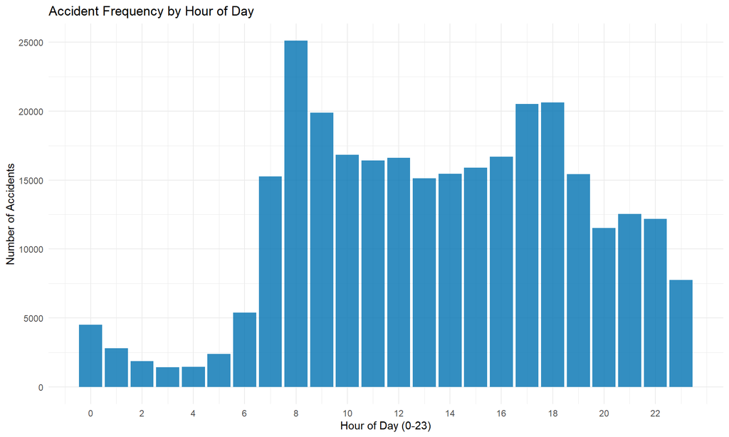

```r
# --- Accidents by Hour of Day ---
ggplot(accidents_agg, aes(x = hour(datetime))) +
  geom_bar(fill = "#0072B2", alpha = 0.8) +
  labs(
    title = "Accident Frequency by Hour of Day",
    x = "Hour of Day (0-23)",
    y = "Number of Accidents"
  ) +
  theme_minimal() +
  scale_x_continuous(breaks = seq(0, 23, 2))
```

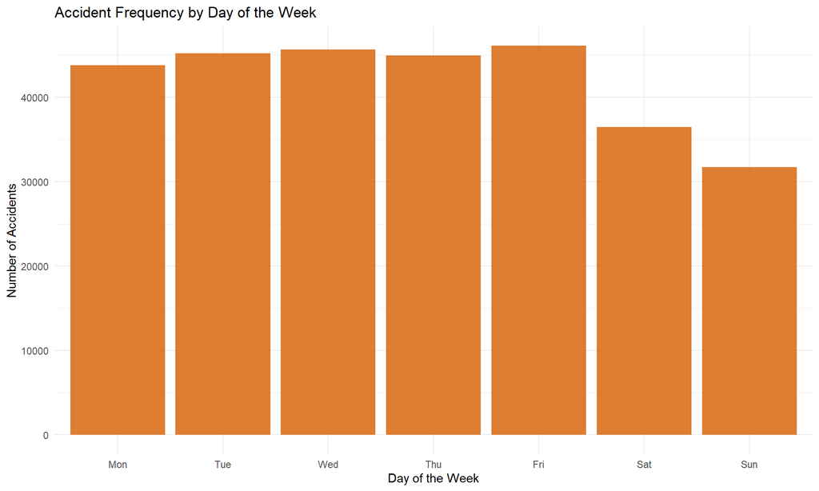

```r
# --- Accidents by Day of the Week ---
accidents_agg[, weekday := lubridate::wday(date, label = TRUE, week_start = 1)]
ggplot(accidents_agg, aes(x = weekday)) +
  geom_bar(fill = "#D55E00", alpha = 0.8) +
  labs(
    title = "Accident Frequency by Day of the Week",
    x = "Day of the Week",
    y = "Number of Accidents"
  ) +
  theme_minimal()
```

## 4.2. Who is involved in accidents? (Demographics)

Let’s look at the age and gender of the parties involved.

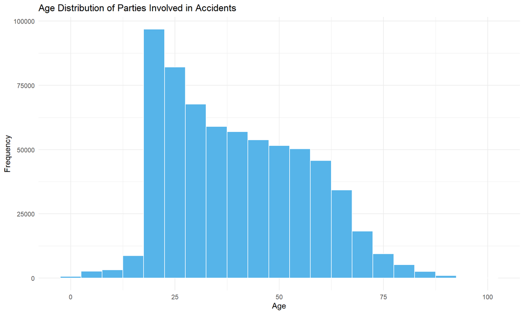

```r
# --- Age Distribution of Parties ---
ggplot(accidents, aes(x = age)) +
  geom_histogram(binwidth = 5, fill = "#56B4E9", color = "white") +
  labs(
    title = "Age Distribution of Parties Involved in Accidents",
    x = "Age",
    y = "Frequency"
  ) +
  theme_minimal()
```

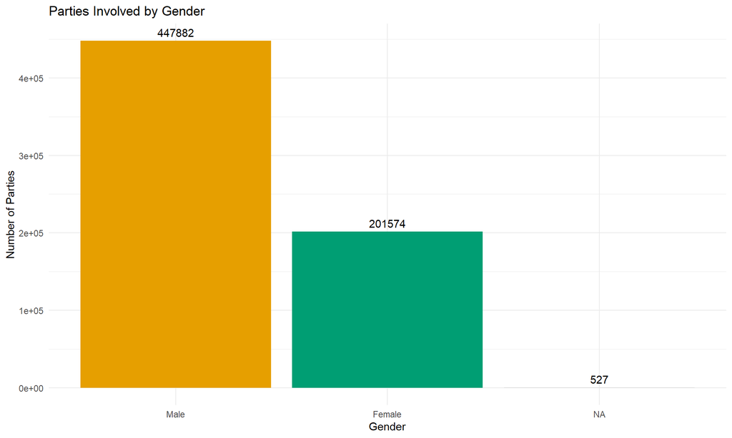

```r
# --- Accidents by Gender ---
accidents %>%
  count(gender_f) %>%
  ggplot(aes(x = reorder(gender_f, -n), y = n)) +
  geom_col(fill = c("#E69F00", "#009E73", "lightgrey")) +
  geom_text(aes(label = n), vjust = -0.5) +
  labs(
    title = "Parties Involved by Gender",
    x = "Gender",
    y = "Number of Parties"
  ) +
  theme_minimal()
```

**Observations:** * The age distribution shows a high number of individuals in their 20s and 30s are involved in accidents. * A significantly higher number of males are involved in accidents compared to females.

## 4.3. What are the circumstances? (Conditions & Vehicle Types)

Here we explore weather conditions, vehicle types, and locations.

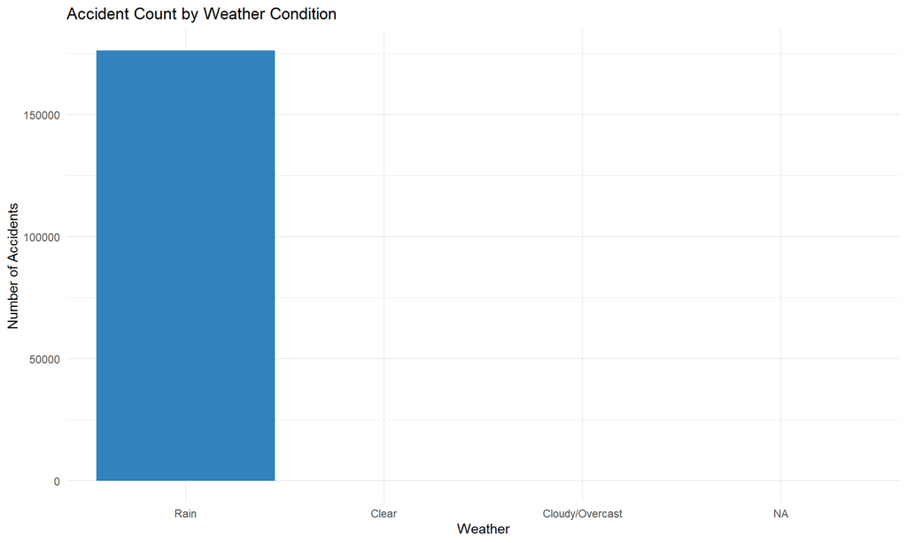

```r
# --- Accidents by Weather Condition ---
accidents_agg %>%
  count(weather_f, sort = TRUE) %>%
  ggplot(aes(x = reorder(weather_f, -n), y = n)) +
  geom_col(aes(fill = weather_f), show.legend = FALSE) +
  labs(
    title = "Accident Count by Weather Condition",
    x = "Weather",
    y = "Number of Accidents"
  ) +
  theme_minimal() +
  scale_fill_brewer(palette = "Blues")
```

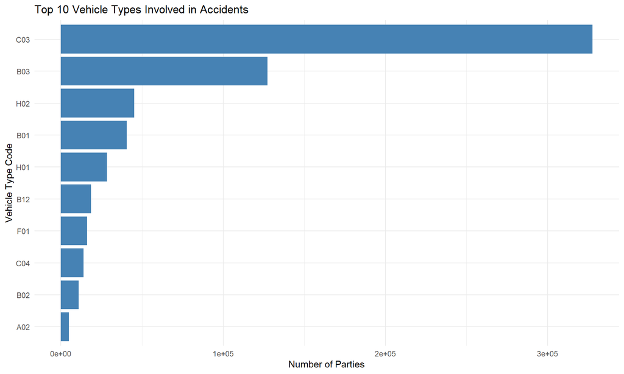

```r
# --- Top 10 Vehicle Types Involved ---
accidents %>%
  count(vehicle_type, sort = TRUE) %>%
  top_n(10, n) %>%
  ggplot(aes(x = reorder(vehicle_type, n), y = n)) +
  geom_col(fill = "steelblue") +
  coord_flip() +
  labs(
    title = "Top 10 Vehicle Types Involved in Accidents",
    x = "Vehicle Type Code",
    y = "Number of Parties"
  ) +
  theme_minimal()
```

## 4.4. Where do accidents occur? (Geospatial Analysis)

We can visualize accident locations by district and create an interactive map.

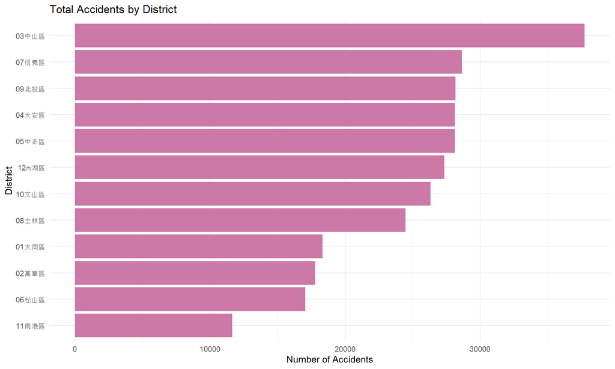

```r
# --- Accidents by District ---
accidents_agg %>%
  count(district_code, sort = TRUE) %>%
  ggplot(aes(x = reorder(district_code, n), y = n)) +
  geom_col(fill = "#CC79A7") +
  coord_flip() +
  labs(
    title = "Total Accidents by District",
    x = "District",
    y = "Number of Accidents"
  ) +
  theme_minimal()
```

```r
# --- Interactive Map of Accident Hotspots ---
# NOTE: Plotting all points is too slow. We take a random sample of 5000.
# Using efficient data.table syntax for sampling.
accidents_sample_map <- accidents_agg[sample(.N, 5000)]

# Approximate coordinates for the center of Taipei
taipei_lat <- 25.0478
taipei_lng <- 121.5319

leaflet(data = accidents_sample_map) %>%
  addProviderTiles(providers$CartoDB.Positron) %>%
  # --- ADD THIS LINE ---
  # Sets the map's center to Taipei with a specific zoom level.
  # Adjust zoom level as needed (e.g., 12 for closer, 10 for wider).
  setView(lng = taipei_lng, lat = taipei_lat, zoom = 11) %>%
  # ---
  addCircleMarkers(
    lng = ~coord_x,
    lat = ~coord_y,
    radius = ~ifelse(total_deaths > 0, 8, 3),
    color = ~ifelse(total_deaths > 0, "red", "blue"),
    stroke = FALSE,
    fillOpacity = 0.5,
    popup = ~paste(
      "<b>District:</b>", district_code, "<br>",
      "<b>Date:</b>", date, "<br>",
      "<b>Injuries:</b>", total_injuries, "<br>",
      "<b>Deaths:</b>", total_deaths
    )
  ) %>%
  addLegend("bottomright",
            colors = c("red", "blue"),
            labels = c("Fatal Accident", "Injury/No-Injury Accident"),
            title = "Accident Severity")
```

[interactive chart not shown]

**Observations:** * Certain districts have a much higher frequency of accidents than others. * The interactive map allows for drilling down into specific locations to see accident details and identify potential hotspots. Fatal accidents are highlighted in red.

# 5. Deeper Dive: Daily and Hourly Patterns

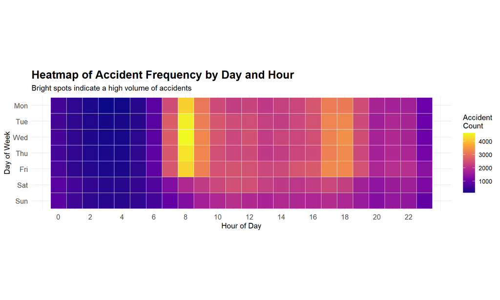

```r
# Add weekday and hour columns to the aggregated accident data
accidents_agg[, weekday := lubridate::wday(datetime, label = TRUE, week_start = 1)]
accidents_agg[, hour := hour(datetime)]

# We also need to merge the daily/hourly weather data into our aggregated table
# For simplicity, we'll merge them back from the original 'accidents' table
# (In a real scenario, you'd have a separate weather table to join)
weather_to_join <- unique(accidents[, .(
  date, daily_precipitation_sum, daily_temperature_2m_mean,
  hourly_precipitation, hourly_temperature_2m, hour = hour(datetime)
)], by = c("date", "hour"))

# Note: This join is simplified. A more robust method would be to create a clean daily/hourly weather key.
# For this exploration, we'll create a summary table directly.

#
# # --- Create a daily summary table ---
# daily_summary <- accidents_agg[, .(
#     num_accidents = .N,
#     # Grab the first value for daily metrics, since they are the same for any given day
#     precipitation = first(daily_precipitation_sum),
#     mean_temp = first(daily_temperature_2m_mean)
#   ), by = date]

# # --- Time Series of Daily Accidents ---
# ggplot(daily_summary, aes(x = date, y = num_accidents)) +
#   geom_line(alpha = 0.5, color = "darkblue") +
#   geom_smooth(method = "loess", se = FALSE, color = "red", span = 0.1) +
#   labs(
#     title = "Total Number of Accidents Per Day",
#     subtitle = "Red line shows the smoothed trend (seasonality)",
#     x = "Date",
#     y = "Number of Unique Accidents"
#   ) +
#   theme_bw()
#
# --- Accidents vs. Daily Precipitation ---
# ggplot(daily_summary, aes(x = precipitation, y = num_accidents)) +
#   geom_point(alpha = 0.4, color = "dodgerblue") +
#   geom_smooth(method = "lm", color = "firebrick") +
#   scale_x_log10(labels = scales::comma) + # Log scale for better visualization of rainfall
#   labs(
#     title = "Does Rain Increase Accidents?",
#     subtitle = "Number of daily accidents vs. total daily precipitation",
#     x = "Total Daily Precipitation (mm) - Log Scale",
#     y = "Number of Unique Accidents"
#   ) +
#   theme_bw()

# --- Create a summary table for the heatmap ---
# Count accidents for each combination of weekday and hour
heatmap_data <- accidents_agg[, .N, by = .(weekday, hour)]

# --- Generate the Heatmap ---
ggplot(heatmap_data, aes(x = hour, y = weekday, fill = N)) +
  geom_tile(color = "white", lwd = 0.1) +
  scale_fill_viridis_c(option = "plasma", name = "Accident\nCount") + # Use a vibrant color scale
  scale_y_discrete(limits = rev) + # Puts Monday at the top
  scale_x_continuous(breaks = seq(0, 23, 2)) +
  labs(
    title = "Heatmap of Accident Frequency by Day and Hour",
    subtitle = "Bright spots indicate a high volume of accidents",
    x = "Hour of Day",
    y = "Day of Week"
  ) +
  coord_equal() + # Makes the tiles square
  theme_minimal() +
  theme(
    plot.title = element_text(size = 16, face = "bold"),
    axis.text = element_text(size = 10)
  )
```

# 6. Conclusion

Further analysis could involve modeling accident severity based on these factors or performing a more in-depth time-series analysis.